# Compulsory Exercise 1

Jostein Gjesdal, Jesper Bengston

2/7/2020

In this task we have a univariate random variable $Y$ and a covariate $x$. Further we have observed a training set of independent pairs
$$\{x_i, y_i\} \thinspace, i \in \mathbb{N}$$

The definition of the MSE_test
$$\begin{equation}
MSE_{test}(x_0)=(Y_0 - \hat{f}(x_0))^2
\end{equation}$$
with y_0 not part of the training set.

$$\begin{align}
MSE_{test} &= E[(Y_i - \hat{f})^2]\\
&= E[ (f + \epsilon - \hat{f} + E[\hat{f}]-E[\hat{f}] )^2 ]\\
&= E[ ( (f -E[\hat{f}]) + \epsilon + (E[\hat{f}] - \hat{f}) )^2 ]\\
&= E[ (f -E[\hat{f}])^2] + E[\epsilon^2] +E[ 2 (E[\hat{f}] - \hat{f})\epsilon] + E[2(f -E[\hat{f}])\epsilon] + E[2(f -E[\hat{f}])( E[\hat{f}] - \hat{f})] + E[(E[\hat{f}] - \hat{f})^2 ]\\
&= E[(f -E[\hat{f}])^2] + E[\epsilon^2] + E[(E[\hat{f}] - \hat{f})^2 ] \\
&= Bias(\hat{f})^2 + \sigma^2+ Var(\hat{f})\\
\end{align}$$

we can interpret the bias as the expected difference between the expected value of the predictor and the true function. meaning how wrong we would on average be if we had an infinite amount of test observations.

the variance is a measure of the spread of a random variable, ie how do they distribute around the mean. A high variance means that we are unsure about each individual observation.

$\sigma²$ is the so called irreducible error, it stems from unobserved covariates and thus with a given model we can never get an error better than this value.

True, a fexible method will be better False, a flexible method will be better as it reduces the bias while the large n prevents overfitting False, a flexible method will risk overfitting a small dataset while providing a negilible reduction in bias True, the flexible method will capture to much of the noise in the system

0.17

C

we use a logistic regression classifier for our data in this task. our predictor is on the form
$$P(Y_i = 1| {\bf X}={\boldsymbol{x}}_i) = p_i = \frac{e^{\beta_0 + \beta_1x_{i1} + \beta_2 x_{i2} + \beta_3x_{i3} + \beta_4 x_{i4}}}{ 1+ e^{\beta_0 + \beta_1x_{i1} + \beta_2x_{i2}+ \beta_3x_{i3} + \beta_4 x_{i4}}} \ ,$$

We abreviate $\beta_0 + \beta_1x_{i1} + \beta_2 x_{i2} + \beta_3x_{i3} + \beta_4 x_{i4}=\beta$ in the following derivation.

$$\begin{align}
\log \left( \frac{p} {1 - p}\right) &= \log \left( p \right)-\log \left(1 - p \right)\\
&= \log \left( \frac {e^\beta} {1 + e^\beta} \right) - \log \left(1 - \frac{e^\beta} {1 + e^\beta} \right)\\
&= \log \left(\frac {e^\beta} {1 + e^\beta} \right) - \log \left( \frac{1 + e^\beta - e^\beta}{1 + e^\beta} \right)\\
&= \log \left(\frac {e^\beta} {1 + e^\beta} \right) - \log \left( \frac{1}{1 + e^\beta} \right)\\
&=\log \left(\frac{ \frac{ e^\beta } { 1 + e^\beta} }{ \frac{1} {1 + e^\beta} } \right)\\
&=\beta\\
\end{align}$$

```r
id <- "1GNbIhjdhuwPOBr0Qz82JMkdjUVBuSoZd"
tennis <- read.csv(sprintf("https://docs.google.com/uc?id=%s&export=download",
    id), header = T)
head(tennis)
```

```
##         Player1      Player2 Result ACE.1 UFE.1 ACE.2 UFE.2
## 1     M.Koehler   V.Azarenka      0     2    18     3    14
## 2    E.Baltacha   F.Pennetta      0     0    10     4    14
## 3     S-W.Hsieh      T.Maria      1     1    13     2    29
## 4      A.Cornet       V.King      1     4    30     0    45
## 5  Y.Putintseva   K.Flipkens      0     2    28     6    19
## 6 A.Tomljanovic B.Jovanovski      0     6    42    11    40
```

```r
glm_tennis =glm(Result ~ ACE.1 + ACE.2 + UFE.1 + UFE.2,data=tennis,family="binomial")
summary(glm_tennis)
```

```
##
## Call:
## glm(formula = Result ~ ACE.1 + ACE.2 + UFE.1 + UFE.2, family = "binomial",
##     data = tennis)
##
## Deviance Residuals:
##     Min       1Q   Median       3Q      Max
## -2.0517  -0.8454   0.3725   0.8773   2.0959
##
## Coefficients:
##             Estimate Std. Error z value Pr(>|z|)
## (Intercept) -0.02438    0.59302  -0.041 0.967211
## ACE.1        0.36338    0.10136   3.585 0.000337 ***
## ACE.2       -0.22388    0.07369  -3.038 0.002381 **
## UFE.1       -0.09847    0.02840  -3.467 0.000527 ***
## UFE.2        0.09010    0.02479   3.635 0.000278 ***
## ---
## Signif. codes:  0 '***' 0.001 '**' 0.01 '*' 0.05 '.' 0.1 ' ' 1
##
## (Dispersion parameter for binomial family taken to be 1)
##
##     Null deviance: 163.04  on 117  degrees of freedom
## Residual deviance: 124.96  on 113  degrees of freedom
## AIC: 134.96
##
## Number of Fisher Scoring iterations: 4
```

ACE.1 has the effect that if we increase it by one we multiply the odds by $\exp{0.36338}$

```r
# create new covariates
tennis$ACEdiff = tennis$ACE.1 - tennis$ACE.2
tennis$UFEdiff = tennis$UFE.1 - tennis$UFE.2


# divide into training and test data
n=dim(tennis)[1]
n2=n/2
set.seed(1234)
train= sample(c(1:n),replace= F)[1:n2]
tennistest= tennis[-train,]
tennistrain=tennis[train,]
```

```r
g = function (obj){
    return(  exp(obj$coefficients %*% c(1,-1,4)) / (1+exp(c(obj$coefficients) %*% c(1,-1,4))))
}
r.tennis = glm(Result ~ ACEdiff + UFEdiff,data=tennistrain, family="binomial")
predict.glm(r.tennis, tennistest,type="response")
```

```
##          1          7         10         11         12         13         15
## 0.42920306 0.29160962 0.67107639 0.61206314 0.33983481 0.58276403 0.28816002
##         18         19         20         23         24         25         27
## 0.26426436 0.58276403 0.50612807 0.48014751 0.20838676 0.71135033 0.70418279
##         29         30         31         33         34         36         37
## 0.82831575 0.54900455 0.39189773 0.24455142 0.20544981 0.89961654 0.49299076
##         39         44         45         46         50         52         53
## 0.90703010 0.41258867 0.70044105 0.90560729 0.80243789 0.25779963 0.91000486
##         55         58         59         60         61         64         65
## 0.30613118 0.88650121 0.66338203 0.60753353 0.76739697 0.34765218 0.26753541
##         68         71         73         74         75         77         83
## 0.42948221 0.46761409 0.59924042 0.42482412 0.85562141 0.49746463 0.71135033
##         85         87         89         91         95         96        100
## 0.79121938 0.78240534 0.13587927 0.20272775 0.49327555 0.31354148 0.40421589
##        102        104        105        106        107        109        110
## 0.81555688 0.82316549 0.59924042 0.57868379 0.48490082 0.77077767 0.44184181
##        112        115        118
## 0.05654078 0.65180652 0.55728861
```

```r
g(r.tennis)
```

```
##           [,1]
## [1,] 0.4292031
```

```r
summary(r.tennis)
```

```
##
## Call:
## glm(formula = Result ~ ACEdiff + UFEdiff, family = "binomial",
##     data = tennistrain)
##
## Deviance Residuals:
##     Min       1Q   Median       3Q      Max
## -1.8546  -0.8968   0.4204   0.8247   1.9382
##
## Coefficients:
##             Estimate Std. Error z value Pr(>|z|)
## (Intercept)  0.28272    0.31175   0.907  0.36447
## ACEdiff      0.22355    0.07959   2.809  0.00497 **
## UFEdiff     -0.08607    0.02832  -3.039  0.00237 **
## ---
## Signif. codes:  0 '***' 0.001 '**' 0.01 '*' 0.05 '.' 0.1 ' ' 1
##
## (Dispersion parameter for binomial family taken to be 1)
##
##     Null deviance: 80.959  on 58  degrees of freedom
## Residual deviance: 63.476  on 56  degrees of freedom
## AIC: 69.476
##
## Number of Fisher Scoring iterations: 4
```

$$x_2=-\frac{\beta_1x}{\beta_2} -\frac{\beta_0}{\beta_2}$$

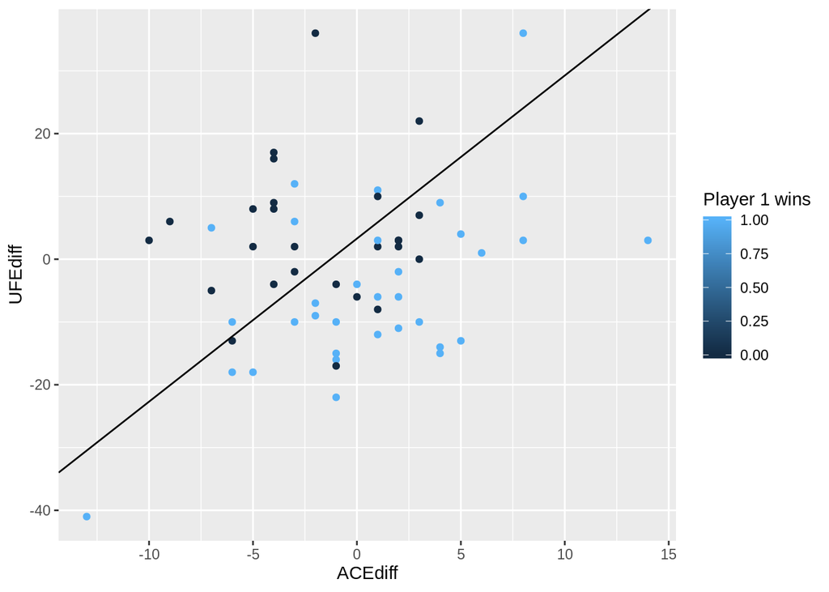

```r
a=r.tennis$coefficients

cept = - a[1] / a[3]
slo= -a[2]/a[3]


ggplot(data=tennistrain, aes(ACEdiff, UFEdiff)) + geom_point(aes(color=Result)) + geom_abline(slope = slo, intercept = cept) + labs(color = "Player 1 wins")
```

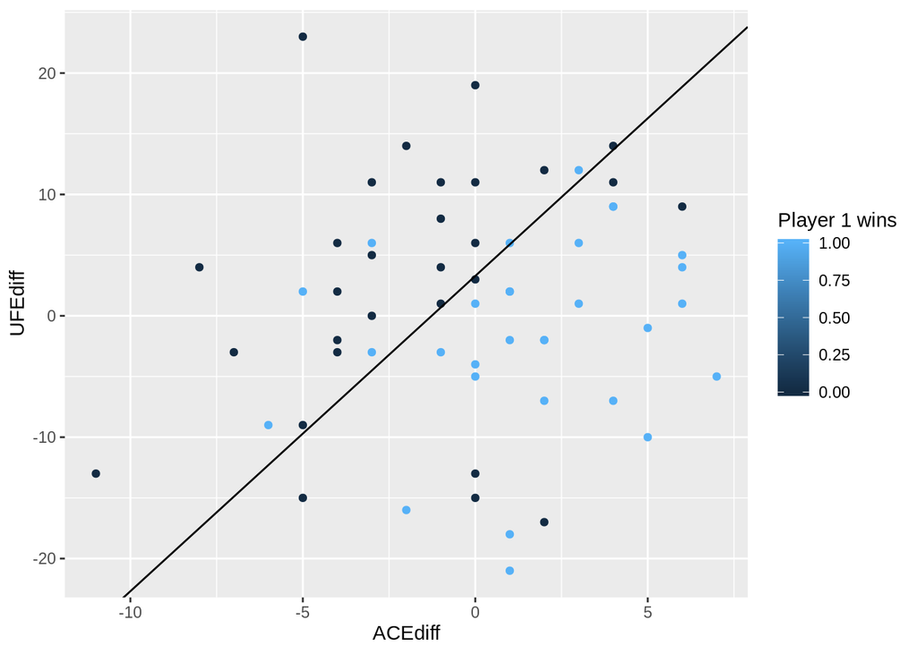

```r
ggplot(data = tennistest, aes(ACEdiff, UFEdiff)) + geom_point(aes(color = Result )) + geom_abline(slope = slo, intercept = cept) + labs(color = "Player 1 wins")
```

```r
confusionmatrix= matrix(0,nrow=2,ncol=2)

for(i in 1:nrow(tennistest))
{
  if(predict(r.tennis,tennistest[i,])>=0.5 && tennistest$Result[i]==1)
  {
    confusionmatrix[1,1]=confusionmatrix[1,1] + 1
  }
  else if (predict(r.tennis, tennistest[i,]) >= 0.5 && tennistest$Result[i] == 0)
  {
    confusionmatrix[1,2]=confusionmatrix[1,2] + 1
  }
  else if(predict(r.tennis,tennistest[i,]) < 0.5 && tennistest$Result[i] == 1)
  {
    confusionmatrix[2,1]=confusionmatrix[2,1] + 1
  }
  else if (predict(r.tennis,tennistest[i,])<0.5 && tennistest$Result[i]==0)
  {
    confusionmatrix[2,2]=confusionmatrix[2,2] + 1
  }
}
confusionmatrix[1,2]
```

```
## [1] 4
```

```r
confusionmatrix
```

```
##      [,1] [,2]
## [1,]   17    4
## [2,]   13   25
```

```r
sensitivity=confusionmatrix[1,1]/(confusionmatrix[1,1]+confusionmatrix[2,1])
selectivity=confusionmatrix[2,2]/(confusionmatrix[1,2]+confusionmatrix[2,2])
sensitivity
```

```
## [1] 0.5666667
```

```r
selectivity
```

```
## [1] 0.862069
```

LDA and QDA analysis In discriminant analysis we try to take an inverse approach from what we use in the regression model.

In the regression model, and KNN methods for that matter, we directly estimate the probability for given class,
$$Pr(Y=k|X=x)$$
In Discriminant analysis we rather find
$$Pr(X=x | Y=k) = f_k(x)= \frac{\exp \left(\frac{-(x-\mu_k)^T \Sigma^{-1}(x-\mu_k)}{2}\right)}{(2\pi)^{p/2} |\Sigma|^{1/2}}$$
We can then use Bayes theorem to find the other probability

Giving the formula:

$$Pr(Y = k | X=x)=\frac{\pi_kf_k(x)}{\sum_{l=1}^n \pi_l f(_l(x)) }$$

with $\pi_k = Pr(Y = k)$, $\Sigma = cov(x)$, $\mu_k = E[f_k(x)]$

assume $n=2, \pi_0=\pi_1=0.5$

$$\begin{align}
&Pr(Y = 0 | X = x) = Pr(Y = 1 | X = x) \\
&= \pi_0 \frac{ \exp \left(\frac{-(x-\mu_k)^T \Sigma^{-1}(x-\mu_k)}{2}\right)}{(2\pi)^{p/2} |\Sigma|^{1/2}} = \pi_1 \frac{ \exp \left(\frac{-(x-\mu_k)^T \Sigma^{-1} (x-\mu_k)}{2}\right)}{(2\pi)^{p/2} |\Sigma|^{1/2}}\\
&\implies \log \left( \pi_0 \frac{ \exp \left(\frac{-(x-\mu_k)^T \Sigma^{-1}(x-\mu_k)}{2}\right)}{(2\pi)^{p/2} |\Sigma|^{1/2}}\right) = \log \left(\pi_1 \frac{ \exp \left(\frac{-(x-\mu_k)^T \Sigma^{-1}(x-\mu_k)}{2}\right)}{(2\pi)^{p/2} |\Sigma|^{1/2}}\right) \\
&\log(\pi_0) -\frac{(x-\mu_0)^T \Sigma^{-1}(x-\mu_0)}{2} = \log(\pi_1) - \frac{(x-\mu_1)^T \Sigma^{-1}(x-\mu_1)}{2}\\
&\log(\pi_0) - \frac{x^T \Sigma^{-1}x-\mu_0^T \Sigma^{-1}x-x^T\Sigma^{-1}\mu_0+\mu_0^T \Sigma^{-1}\mu_0}{2} = \log(\pi_1) - \frac{x^T \Sigma^{-1}x - \mu_1^T \Sigma^{-1}x - x^T\Sigma^{-1}\mu_1 + \mu_1^T \Sigma^{-1}\mu_1}{2}\\
&\log(\pi_0) + x^T\Sigma^{-1}\mu_0 - \frac{\mu_0^T \Sigma^{-1}\mu_0}{2} = \log(\pi_1) + x^T\Sigma^{-1}\mu_1 - \frac{\mu_1^T \Sigma^{-1}\mu_1}{2}\\
\end{align}$$

```r
cov1=cov(cbind(tennistrain$ACEdiff, tennistrain$UFEdiff))
mean(tennistrain$ACEdiff)
```

```
## [1] -0.4915254
```

```r
mu02=mean(tennistrain$UFEdiff)
mu02
```

```
## [1] -1.169492
```

```r
invcov = solve(cov1)

mu01=mean(tennistrain[tennistrain$Result==0,]$ACEdiff)
mu02=mean(tennistrain[tennistrain$Result==0,]$UFEdiff)
mu11=mean(tennistrain[tennistrain$Result==1,]$ACEdiff)
mu12=mean(tennistrain[tennistrain$Result==1,]$UFEdiff)
pi1=length(tennistrain[tennistrain$Result==1,]$Result)/length(tennistrain$Result)
pi1
```

```
## [1] 0.559322
```

```r
pi0=1-pi1
invcov
```

```
##              [,1]         [,2]
## [1,]  0.045690674 -0.004086535
## [2,] -0.004086535  0.006213270
```

```r
A=invcov[1,1]
B=invcov[1,2]
C=invcov[2,1]
D=invcov[2,2]
```

$$\begin{align}
Pr(Y = 1 | X=x) &= \frac{\pi_1 f_1(x)}{\sum_{l=0}^1 \pi_l f(_l(x)) }= 1/2\\
&\pi_1f_1(x) = \frac{\sum_{l=0}^1 \pi_l f(_l(x))}{2}\\
&\log(\pi_1f_1(x)) = \log(\pi_0 f_0(x))\\
&\log(\pi_0) + x^T\Sigma^{-1}\mu_0 - \frac{\mu_0^T \Sigma^{-1}\mu_0}{2} = \log(\pi_1) + x^T\Sigma^{-1}\mu_1 - \frac{\mu_1^T \Sigma^{-1}\mu_1}{2}\\
&\log(\pi_0) + x^T\Sigma^{-1}\mu_0 - x^T\Sigma^{-1}\mu_1 = \log(\pi_1) +\frac{\mu_0^T \Sigma^{-1} \mu_0 - \mu_1^T \Sigma^{-1} \mu_1}{2}\\
& x^T\Sigma^{-1}\mu_0 - x^T\Sigma^{-1}\mu_1 = \log(\pi_1)-\log(\pi_0)+\frac{\mu_0^T \Sigma^{-1} \mu_0 - \mu_1^T \Sigma^{-1} \mu_1}{2}\\
&\mu_{01}(Ax_1+Bx_2)+\mu_{02}(Bx_1+Cx_2)-(\mu_{11}(Ax_1+Bx_2)\mu_{12}(Bx_1+Cx_2))=\log(\pi_1)-\log(\pi_0)+\frac{\mu_0^T \Sigma^{-1} \mu_0 - \mu_1^T \Sigma^{-1} \mu_1}{2}\\
&(B(\mu_{01}-\mu_{11})+C(\mu_{02}-\mu_{12}))x_2=-x_1(A(\mu_{01}-\mu_{11})+B(\mu_{02}-\mu_{12}))+\log(\pi_1)-\log(\pi_0)+\frac{\mu_0^T \Sigma^{-1} \mu_0 - \mu_1^T \Sigma^{-1} \mu_1}{2}\\
\end{align}$$

$$a=\frac{(A(\mu_{01}-\mu_{11})+B(\mu_{02}-\mu_{12}))}{(B(\mu_{01}-\mu_{11})+C(\mu_{02}-\mu_{12}))}$$

```r
slopestyle= 2*B*(mu12 + mu02)/ (2*B*(mu01 - mu01) + 2*D*(mu02^2 - mu12^2))
slopestyle
```

```
## [1] -0.07507196
```

```r
interloper= (- 2*B*(mu11*mu12 + mu01*mu02) - A*(mu11^2 - mu01^2)  - log( pi1 / pi0) - D*(mu12^2 - mu02^2)) / (2*B*(mu01 - mu01) + 2*D*(mu02^2 - mu12^2))
interloper
```

```
## [1] 1.645162
```

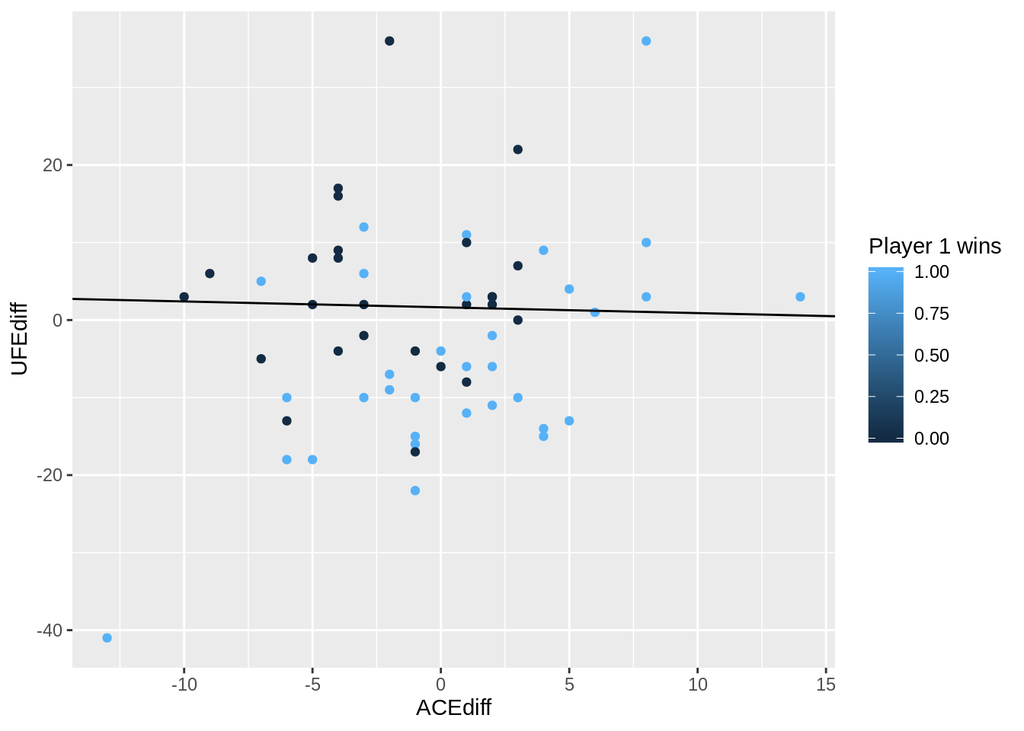

```r
ggplot(data=tennistrain, aes(ACEdiff,UFEdiff)) + geom_point(aes(color=Result)) + geom_abline(slope =slopestyle , intercept = interloper) + labs(color = "Player 1 wins")
```

```r
lda.tennis=lda(Result ~ ACEdiff+UFEdiff,tennistrain, priors=c(pi0, pi1))
summary(lda.tennis)
```

```
##         Length Class  Mode
## prior   2      -none- numeric
## counts  2      -none- numeric
## means   4      -none- numeric
## scaling 2      -none- numeric
## lev     2      -none- character
## svd     1      -none- numeric
## N       1      -none- numeric
## call    4      -none- call
## terms   3      terms  call
## xlevels 0      -none- list
```

```r
classes = predict(lda.tennis,tennistest)$class
lda.confusionmatrix=matrix(c(0,0,0,0),nrow=2,ncol=2)
for( i in 1:nrow(tennistest))
{if (classes[i]==tennistest$Result[i])
  { if(tennistest$Result[i] == 1)
    {
    lda.confusionmatrix[2,2] = lda.confusionmatrix[2,2]+1
    }else { lda.confusionmatrix[1,1] = lda.confusionmatrix[1,1]+1}
}else
  { if(tennistest$Result[i] == 1)
    {
      lda.confusionmatrix[1,2] = lda.confusionmatrix[1,2]+1
    }else { lda.confusionmatrix[2,1] = lda.confusionmatrix[2,1]+1}}
}

lda.confusionmatrix
```

```
##      [,1] [,2]
## [1,]   20    5
## [2,]    9   25
```

```r
qda.tennis=qda(Result ~ ACEdiff+UFEdiff,tennistrain, priors=c(pi0, pi1))
summary(qda.tennis)
```

```
##         Length Class  Mode
## prior   2      -none- numeric
## counts  2      -none- numeric
## means   4      -none- numeric
## scaling 8      -none- numeric
## ldet    2      -none- numeric
## lev     2      -none- character
## N       1      -none- numeric
## call    4      -none- call
## terms   3      terms  call
## xlevels 0      -none- list
```

```r
classes = predict(qda.tennis,tennistest)$class
qda.confusionmatrix=matrix(c(0,0,0,0),nrow=2,ncol=2)
for( i in 1:nrow(tennistest))
{if (classes[i]==tennistest$Result[i])
  { if(tennistest$Result[i] == 1)
    {
    qda.confusionmatrix[2,2] = qda.confusionmatrix[2,2]+1
    }else { qda.confusionmatrix[1,1] = qda.confusionmatrix[1,1]+1}
}else
  { if(tennistest$Result[i] == 1)
    {
      qda.confusionmatrix[1,2] = qda.confusionmatrix[1,2]+1
    }else { qda.confusionmatrix[2,1] = qda.confusionmatrix[2,1]+1}}
}

qda.confusionmatrix
```

```
##      [,1] [,2]
## [1,]   20    6
## [2,]    9   24
```

Based on the confusion matricies produced we would conclude that lda is the appropriate model.

10-fold cross validation: To perform a 10 fold crossvalidation we will seperate the system into 10 parts and use 9/10th of the avalible data to train and the last 10th to validate.

to calculate the total training error we would use standard MSE on each of the 10 training sets, and then average over them to find CV.

TRUE, TRUE, FALSE, FALSE

```r
id <- "1I6dk1fA4ujBjZPo3Xj8pIfnzIa94WKcy"  # google file ID
d.chd <- read.csv(sprintf("https://docs.google.com/uc?id=%s&export=download",
    id))

r.chd = glm(chd ~ sbp + sex ,data = d.chd, family="binomial")
summary(r.chd)
```

```
##
## Call:
## glm(formula = chd ~ sbp + sex, family = "binomial", data = d.chd)
##
## Deviance Residuals:
##     Min       1Q   Median       3Q      Max
## -1.0647  -0.8697  -0.7749   1.4191   1.7794
##
## Coefficients:
##              Estimate Std. Error z value Pr(>|z|)
## (Intercept) -2.386252   0.790657  -3.018  0.00254 **
## sbp          0.011337   0.006273   1.807  0.07075 .
## sex          0.322764   0.235786   1.369  0.17103
## ---
## Signif. codes:  0 '***' 0.001 '**' 0.01 '*' 0.05 '.' 0.1 ' ' 1
##
## (Dispersion parameter for binomial family taken to be 1)
##
##     Null deviance: 427.61  on 349  degrees of freedom
## Residual deviance: 422.63  on 347  degrees of freedom
## AIC: 428.63
##
## Number of Fisher Scoring iterations: 4
```

```r
chd.coefs = r.chd$coefficients
truemean = exp(c(chd.coefs) %*% c(1,140,1))/(1+exp(c(chd.coefs) %*% c(1,140,1)))
```

```r
f =function(obj)
  {
    return(  exp(obj$coefficients %*% c(1,140,1)) / (1+exp(c(obj$coefficients) %*% c(1,140,1))))
  }

B=1000
est = rep(NA, B)
sample_n(d.chd,350,replace = TRUE)
```

[output not shown]

[output cut: 336 more lines]

```r
for (i in 1:B)
{
  x = sample_n(d.chd,350,replace = TRUE)
  thisreg = glm(chd ~ sbp + sex ,data = x, family="binomial")

  est[i] = f(thisreg)

}

sd(est)
```

```
## [1] 0.04792577
```

```r
quantile(est,c(0.025,0.975))
```

```
##      2.5%     97.5%
## 0.2903954 0.4755589
```

When we find the confidence interval using bootstrapping we are finding the uncertanty in our estimate of the probability.